# Introduction to JupyterLab

## What is Jupyter?

- Jupyter grew out of another project called interactive python, or ipython
- The name jupyter is a portmanteau of julia, python, and R
- [JupyterLab](https://jupyterlab.readthedocs.io/en/latest/) is a web-based development environment including notebooks, editors, terminals, etc.

## Why use Jupyter?

- to make pretty pages like this one
- interactive code development
- to make interactive scripts for other people to use
- to record your workflow (ie, as a lab book)

# Exercise 1: starting a session

- Go to https://ondemand.talapas.uoregon.edu/
- Login
- Choose `Clusters -> Shell access`
- Before you go, run these commands:
  - `echo $PATH | grep -o : | wc -l` # show how many paths are in your `$PATH`
  - `env | wc -l` # show how many variables are defined in your environment
- Go to interactive apps and start a jupyter lab session
  - Default options are fine
  - Leave custom conda environment unchecked

[emwin@login2 ~]$ echo $PATH | grep -o : | wc -l 8 [emwin@login2 ~]$ env | wc -l 75

# The Jupyter Lab Interface

## Left sidebar: shows the file browser, running kernels, etc.

- File browser: You can only navigate to folders beneath your own home folder. You can upload and download files to your local computer here.
- Running kernels: Shows open tabs and running kernels.
  - Open tabs: self explanatory
  - Kernels: running kernels and the notebooks using them. Notebooks can share a kernel but things can get weird.
  - Language servers: You will probably never use this, the functionality is disabled by default
  - Terminals: Any open terminals (they'll also show under tabs)
  - Workspaces: Newer versions of Jupyter Lab will also show workspaces here
- Table of contents: shows markdown headers
- Extension manager: jupyter lab add-ons
- Software modules: shows modules that have been loaded, or that can be loaded. LOADING MODULES HERE IS NOT RECOMMENDED.

## Right sidebar: property inspector and debugger

- Property inspector
  - Common tools: you can write protect individual cells and add tags
  - Advanced tools: beyond the scope of this workshop
- Debugger: also beyond the scope of this workshop

## Menu bar

- File
- Edit
- View
- Run
- Kernel
- Tabs
- Settings
- Help

## Main work area

Where your tabs for your notebooks, terminals, launchers, editor, etc are.

# Exercise 2: The terminal

- Click the blue "+" button that says "New Launcher" when you hover over it, or choose the Launcher tab if it's already open
- Create a terminal
- Are you on a login node?
- Try these commands:

```
ls /cephfs # This is the remote storage location for research groups
python3 --version
python --version
echo $PATH | grep -o : | wc -l
env | wc -l
module list
module purge
echo $PATH | grep -o : | wc -l
env | wc -l
```

[emwin@n0398 jupyter-f26]$ hostname n0398.talapas.uoregon.edu [emwin@n0398 jupyter-f26]$ ls /cephfs # This is the remote storage location for research groups ls: cannot access '/cephfs': No such file or directory [emwin@n0398 jupyter-f26]$ python3 --version Python 3.15.2 [emwin@n0398 jupyter-f26]$ python --version Python 3.15.2 [emwin@n0398 jupyter-f26]$ echo $PATH | grep -o : | wc -l 21 [emwin@n0398 jupyter-f26]$ env | wc -l 368 [emwin@n0398 jupyter-f26]$ module list Currently Loaded Modules: 1) latex/20250228 2) miniconda3/20260319 [emwin@n0398 jupyter-f26]$ module purge Warning: Conda environment still active. Run 'conda deactivate' before unloading. [emwin@n0398 jupyter-f26]$ echo $PATH | grep -o : | wc -l 16 [emwin@n0398 jupyter-f26]$ env | wc -l 348

- Now try `ssh login.talapas.uoregon.edu` and repeat the first six commands. When you're done, don't forget to `exit`.

[emwin@login2 ~]$ ls /cephfs # This is the remote storage location for research groups ... [emwin@login2 ~]$ python3 --version Python 3.6.8 [emwin@login2 ~]$ python --version -bash: python: command not found [emwin@login2 ~]$ module list No modules loaded [emwin@login2 ~]$ module purge [emwin@login2 ~]$ echo $PATH | grep -o : | wc -l 8

## Takeaways from exercise 2

- You can only browse the `/cephfs` volume (large scale research storage) from a login node
- You can get to a login node using ssh
- The commands you run may give different results depending on your current environment
- `module purge` does not get you back to the same environment you would have on a login node, or in a talapas desktop session

# Conda environments and JupyterLab

- The default jupyter lab OnDemand app is running in a conda environment that you can't modify
- If you build your own conda environment that includes Jupyter, you can:
  - use a more recent Jupyter version
  - use a more recent python version
  - add support for more kernels, such as R
  - create custom kernels
  - add python packages you need

## jupyter.yml example file

```
name: myjupyter
channels:
  - conda-forge
dependencies:
  - numpy
  - pandas
  - seaborn
  - jupyter
  - r-base
  - r-essentials
  - r-irkernel
  - nodejs
  - ipywidgets
  - pip
  - pip:
    - git+https://github.com/conery/nbscan.git
```

# Exercise 3: Creating and saving notebooks

- Click the blue "+" button that says "New Launcher" when you hover over it
- Create a new notebook using the ipykernel
- Choose File->Save Notebook As and give the notebook a name
- Look at the tabs with the notebook names. If there's a solid circle next to the name, it indicates unsaved changes. After it autosaves it changes to ×
- Hovering over the tab will show you the name, path, last save, and last checkpoint
- To make a checkpoint: use the save icon or hit Ctrl-S.
- You can revert to the last checkpoint, but not further back than that -- there is only one checkpoint at a time.
- Look at Open Tabs and Running Kernels. If you close a notebook, does the kernel stop?

# Interactive python

Everything after this will focus on notebooks using the interactive python kernel ipykernel. Other kernels (eg R) will not have all of these features!

## Cells

Notebooks consist of cells. There are three types:

- Markdown: like this one. They look nice.
- Raw: good for comments
- Code: for actually doing things

This is a raw cell.

After you type something into a cell, hit the "play" button or shift-enter to run it.

Code cells run any code within the cell, and show stdout and stderr beneath the cell. If the code cell returns a value, it will be shown as an output cell.

```python
# this is a code cell. It returns a value
'Hello ' + 'World'
```

```
'Hello World'
```

```python
# this code cell prints to std out
print('Hello World')
```

```
Hello World
```

```python
# this code cell has an error
pirnt('Hello World')
```

```
---------------------------------------------------------------------------
NameError                                 Traceback (most recent call last)
Cell In[3], line 2
      1 # this code cell has an error
----> 2 pirnt('Hello World')

NameError: name 'pirnt' is not defined
```

We can edit and rerun cells, copy them, drag them around, etc. Be careful about doing too much of that if you are using the notebook as a lab book.

## Variables and Functions

Variables and functions defined in a cell are accessible anywhere in the rest of the notebook.

```python
hw = 'Hello ' + 'World'
print(hw)
```

```
Hello World
```

```python
hw
```

```
'Hello World'
```

```python
def hello(input):
    print('Hello ' + input)
```

```python
hello('World')
```

```
Hello World
```

```python
def goodbye(input):
    return 'Goodbye ' + input
```

```python
goodbye('World')
```

```
'Goodbye World'
```

```python
gw = goodbye('World')
```

```python
gw
```

```
'Goodbye World'
```

You can suppress the returned value by adding a semicolon at the end -- if you're a matlab user this will be familiar

```python
goodbye('World');
```

##### In & Out

See those numbers next to some output cells? There are two special containers called "In" and "Out". All code cells go into the "In" container. All output cells go into the "Out" container. Those containers are saved during the current session, no matter how many times you re-execute a code cell.

```python
In
```

```
['',
 "# this is a code cell. It returns a value\n'Hello ' + 'World'",
 "# this code cell prints to std out\nprint('Hello World')",
 "# this code cell has an error\npirnt('Hello World')",
 "hw = 'Hello ' + 'World'\nprint(hw)",
 'hw',
 "def hello(input):\n    print('Hello ' + input)",
 "hello('World')",
 "def goodbye(input):\n    return 'Goodbye ' + input",
 "goodbye('World')",
 "gw = goodbye('World')",
 'gw',
 "goodbye('World');",
 'In']
```

```python
Out
```

```
{1: 'Hello World',
 5: 'Hello World',
 9: 'Goodbye World',
 11: 'Goodbye World',
 13: ['',
  "# this is a code cell. It returns a value\n'Hello ' + 'World'",
  "# this code cell prints to std out\nprint('Hello World')",
  "# this code cell has an error\npirnt('Hello World')",
  "hw = 'Hello ' + 'World'\nprint(hw)",
  'hw',
  "def hello(input):\n    print('Hello ' + input)",
  "hello('World')",
  "def goodbye(input):\n    return 'Goodbye ' + input",
  "goodbye('World')",
  "gw = goodbye('World')",
  'gw',
  "goodbye('World');",
  'In',
  'Out']}
```

'In' is a python list and 'Out' is a python dict. Notice what's not in Out: anything written to stdout or stderr. This will matter when we introduce logging.

```python
In[1]
```

```
"# this is a code cell. It returns a value\n'Hello ' + 'World'"
```

```python
Out[1]
```

```
'Hello World'
```

There's a shortcut to get the last output: _

```python
_
```

```
'Hello World'
```

## Getting help

To get help with any command or variable in an ipython notebook: add a question mark.

```python
In?
```

```
Type:        list
String form: ['', "# this is a code cell. It returns a value\n'Hello ' + 'World'", "# this code cell prints to <...> e('World');", 'In', 'Out', 'In[1]', 'Out[1]', '_', "get_ipython().run_line_magic('pinfo', 'In')"]
Length:      19
Docstring:
Built-in mutable sequence.

If no argument is given, the constructor creates a new empty list.
The argument must be an iterable if specified.
```

```python
Out?
```

```
Type:        dict
String form: {1: 'Hello World', 5: 'Hello World', 9: 'Goodbye World', 11: 'Goodbye World', 13: ['', "# this is <...> is is a code cell. It returns a value\n'Hello ' + 'World'", 16: 'Hello World', 17: 'Hello World'}
Length:      8
Docstring:
dict() -> new empty dictionary
dict(mapping) -> new dictionary initialized from a mapping object's
    (key, value) pairs
dict(iterable) -> new dictionary initialized as if via:
    d = {}
    for k, v in iterable:
        d[k] = v
dict(**kwargs) -> new dictionary initialized with the name=value pairs
    in the keyword argument list.  For example:  dict(one=1, two=2)
```

```python
print?
```

```
Signature: print(*objects, sep=' ', end='\n', file=None, flush=False)
Docstring:
Prints the values to a stream, or to sys.stdout by default.

sep
  string inserted between values, default a space.
end
  string appended after the last value, default a newline.
file
  a file-like object (stream); defaults to the current sys.stdout.
flush
  whether to forcibly flush the stream.
Type:      builtin_function_or_method
```

## Logging

The ipykernel has a built-in logging command which can let us use jupyter as an electronic lab book.

```python
%logstart?
```

```
Docstring:
Start logging anywhere in a session.

%logstart [-o|-r|-t|-q] [log_name [log_mode]]

If no name is given, it defaults to a file named 'ipython_log.py' in your
current directory, in 'rotate' mode (see below).

'%logstart name' saves to file 'name' in 'backup' mode.  It saves your
history up to that point and then continues logging.

%logstart takes a second optional parameter: logging mode. This can be one
of (note that the modes are given unquoted):

append
    Keep logging at the end of any existing file.

backup
    Rename any existing file to name~ and start name.

global
    Append to  a single logfile in your home directory.

over
    Overwrite any existing log.

rotate
    Create rotating logs: name.1~, name.2~, etc.

Options:

  -o
    log also IPython's output. In this mode, all commands which
    generate an Out[NN] prompt are recorded to the logfile, right after
    their corresponding input line. The output lines are always
    prepended with a '#[Out]# ' marker, so that the log remains valid
    Python code.

  Since this marker is always the same, filtering only the output from
  a log is very easy, using for example a simple awk call::

    awk -F'#\[Out\]# ' '{if($2) {print $2}}' ipython_log.py

  -r
    log 'raw' input.  Normally, IPython's logs contain the processed
    input, so that user lines are logged in their final form, converted
    into valid Python.  For example, %Exit is logged as
    _ip.run_line_magic("Exit").  If the -r flag is given, all input is logged
    exactly as typed, with no transformations applied.

  -t
    put timestamps before each input line logged (these are put in
    comments).

  -q
    suppress output of logstate message when logging is invoked
File:      ~/.conda/envs/pandas-f26/lib/python3.15/site-packages/IPython/core/magics/logging.py
```

```python
%logstart
```

```
Activating auto-logging. Current session state plus future input saved.
Filename       : ipython_log.py
Mode           : rotate
Output logging : False
Raw input log  : False
Timestamping   : False
State          : active
```

```python
%logstop
```

```python
%logstart -r -t -o 'mylog_20261029.log' append
```

```
Activating auto-logging. Current session state plus future input saved.
Filename       : mylog_20261029.log
Mode           : append
Output logging : True
Raw input log  : True
Timestamping   : True
State          : active
```

# Exercise 4: Logging

- Go to the notebook you created in exercise 3.
- Run some commands in code cells (anything you like, errors are fine)
- Start a log using the '-t' timestamp option
- Run some more commands
- Inspect the log file using the editor

get_ipython().run_line_magic('pinfo', 'In') get_ipython().run_line_magic('pinfo', 'Out') get_ipython().run_line_magic('pinfo', 'print') get_ipython().run_line_magic('pinfo', '%logstart') get_ipython().run_line_magic('logstart', '') get_ipython().run_line_magic('logstop', '')

# Magic commands

`%logstart` and `%logstop` are examples of 'magic commands'. The ipykernel has "cell magics" and "line magics". Cell magics start with %%, and line magics start with %. You can read about the [cell and line magics available to you from within JupyterLab](https://ipython.readthedocs.io/en/stable/interactive/magics.html#cell-magics) on this documentation page, or by running the `%magic` line magic.

```python
%magic
```

```
IPython's 'magic' functions
===========================

The magic function system provides a series of functions which allow you to
control the behavior of IPython itself, plus a lot of system-type
features. There are two kinds of magics, line-oriented and cell-oriented.

Line magics are prefixed with the % character and work much like OS
command-line calls: they get as an argument the rest of the line, where
arguments are passed without parentheses or quotes.  For example, this will
time the given statement::

        %timeit range(1000)

Cell magics are prefixed with a double %%, and they are functions that get as
an argument not only the rest of the line, but also the lines below it in a
separate argument.  These magics are called with two arguments: the rest of the
call line and the body of the cell, consisting of the lines below the first.
For example::

        %%timeit x = numpy.random.randn((100, 100))
        numpy.linalg.svd(x)

will time the execution of the numpy svd routine, running the assignment of x
as part of the setup phase, which is not timed.

In a line-oriented client (the terminal or Qt console IPython), starting a new
input with %% will automatically enter cell mode, and IPython will continue
reading input until a blank line is given.  In the notebook, simply type the
whole cell as one entity, but keep in mind that the %% escape can only be at
the very start of the cell.

NOTE: If you have 'automagic' enabled (via the command line option or with the
%automagic function), you don't need to type in the % explicitly for line
magics; cell magics always require an explicit '%%' escape.  By default,
IPython ships with automagic on, so you should only rarely need the % escape.

Example: typing '%cd mydir' (without the quotes) changes your working directory
to 'mydir', if it exists.

```

[output cut: 2911 more lines]

```
    positional arguments:
      filename      file to write

    options:
      -a, --append  Append contents of the cell to an existing file. The file will
                    be created if it does not exist.

Summary of magic functions (from %lsmagic):
Available line magics:
%alias  %alias_magic  %autoawait  %autocall  %automagic  %autosave  %bookmark  %cat  %cd  %clear  %code_wrap  %colors  %conda  %config  %connect_info  %cp  %debug  %dhist  %dirs  %doctest_mode  %ed  %edit  %env  %gui  %hist  %history  %killbgscripts  %ldir  %less  %lf  %lk  %ll  %load  %load_ext  %l…

Available cell magics:
%%!  %%HTML  %%SVG  %%bash  %%capture  %%code_wrap  %%debug  %%file  %%html  %%javascript  %%js  %%latex  %%markdown  %%perl  %%prun  %%pypy  %%python  %%python2  %%python3  %%ruby  %%script  %%sh  %%svg  %%sx  %%system  %%time  %%timeit  %%writefile

Automagic is ON, % prefix IS NOT needed for line magics.
```

There's a magic command called `%automagic` that lets you leave the `%` off of line magics. It's set to `on` by default. I've included the `%` in front of all of the line magics in this notebook for clarity. There are far too many useful magics to go over them all, but here's one to show all the variables we've defined in this notebook:

```python
%who
```

```
goodbye	 gw	 hello	 hw
```

Just like any other variable or function, we can add a question mark to see more. A double question mark will show the code.

```python
hello?
```

```
Signature: hello(input)
Docstring: <no docstring>
File:      /tmp/ipykernel_2008590/3580921801.py
Type:      function
```

```python
hello??
```

```
Signature: hello(input)
Docstring: <no docstring>
Source:
def hello(input):
    print('Hello ' + input)
File:      /tmp/ipykernel_2008590/3580921801.py
Type:      function
```

## `%alias`

We can use the `%alias` magic to save common shell commands as line magics. Several are already defined.

```python
%alias
```

```
Total number of aliases: 12
```

```
[('cat', 'cat'),
 ('cp', 'cp'),
 ('ldir', 'ls -F -o --color %l | grep /$'),
 ('lf', 'ls -F -o --color %l | grep ^-'),
 ('lk', 'ls -F -o --color %l | grep ^l'),
 ('ll', 'ls -F -o --color'),
 ('ls', 'ls -F --color'),
 ('lx', 'ls -F -o --color %l | grep ^-..x'),
 ('mkdir', 'mkdir'),
 ('mv', 'mv'),
 ('rm', 'rm'),
 ('rmdir', 'rmdir')]
```

ls, cat are both aliases

```python
%cat jupyter.yml
```

```
name: myjupyter
channels:
  - conda-forge
dependencies:
  - numpy
  - pandas
  - seaborn
  - jupyter
  - r-base
  - r-essentials
  - r-irkernel
  - nodejs
  - ipywidgets
  - pip
  - pip:
    - git+https://github.com/conery/nbscan.git
```

```python
%ls /projects/racs_training/intro-hpc-f26/talapas-scripting
```

```
a-slow-script.sh  greeting.txt*  scout.png
bash-where-who/   read-only.txt  slurm-greeting.sbatch
```

We can define new aliases.

```python
%alias head head
```

```python
%head jupyter.yml
```

```
name: myjupyter
channels:
  - conda-forge
dependencies:
  - numpy
  - pandas
  - seaborn
  - jupyter
  - r-base
  - r-essentials
```

Notice that `%cd` is NOT an alias, but it is a `%magic`. Why? Because if we cd'd inside a cell using the system, when we left the cell we'd go back to where we were.

```python
cd?
```

```
Docstring:
Change the current working directory.

This command automatically maintains an internal list of directories
you visit during your IPython session, in the variable ``_dh``. The
command :magic:`%dhist` shows this history nicely formatted. You can
also do ``cd -<tab>`` to see directory history conveniently.
Usage:

  - ``cd 'dir'``: changes to directory 'dir'.
  - ``cd -``: changes to the last visited directory.
  - ``cd -<n>``: changes to the n-th directory in the directory history.
  - ``cd --foo``: change to directory that matches 'foo' in history
  - ``cd -b <bookmark_name>``: jump to a bookmark set by %bookmark
  - Hitting a tab key after ``cd -b`` allows you to tab-complete
    bookmark names.

  .. note::
    ``cd <bookmark_name>`` is enough if there is no directory
    ``<bookmark_name>``, but a bookmark with the name exists.

Options:

-q               Be quiet. Do not print the working directory after the
                  cd command is executed. By default IPython's cd
                  command does print this directory, since the default
                  prompts do not display path information.

.. note::
   Note that ``!cd`` doesn't work for this purpose because the shell
   where ``!command`` runs is immediately discarded after executing
   'command'.

Examples
--------
::

  In [10]: cd parent/child
  /home/tsuser/parent/child
File:      ~/.conda/envs/pandas-f26/lib/python3.15/site-packages/IPython/core/magics/osm.py
```

If you're really curious you can see the source code for it.

```python
cd??
```

```
Source:
    @skip_doctest
    @line_magic
    def cd(self, parameter_s=''):
        """Change the current working directory.

        This command automatically maintains an internal list of directories
        you visit during your IPython session, in the variable ``_dh``. The
        command :magic:`%dhist` shows this history nicely formatted. You can
        also do ``cd -<tab>`` to see directory history conveniently.
        Usage:

          - ``cd 'dir'``: changes to directory 'dir'.
          - ``cd -``: changes to the last visited directory.
          - ``cd -<n>``: changes to the n-th directory in the directory history.
          - ``cd --foo``: change to directory that matches 'foo' in history
          - ``cd -b <bookmark_name>``: jump to a bookmark set by %bookmark
          - Hitting a tab key after ``cd -b`` allows you to tab-complete
            bookmark names.

          .. note::
            ``cd <bookmark_name>`` is enough if there is no directory
            ``<bookmark_name>``, but a bookmark with the name exists.

        Options:

        -q               Be quiet. Do not print the working directory after the
                          cd command is executed. By default IPython's cd
                          command does print this directory, since the default
                          prompts do not display path information.

        .. note::
           Note that ``!cd`` doesn't work for this purpose because the shell
           where ``!command`` runs is immediately discarded after executing
           'command'.

        Examples
        --------
        ::

```

[output cut: 81 more lines]

```
                    self.shell.db['dhist'] = compress_dhist(dhist)[-100:]

        else:
            os.chdir(self.shell.home_dir)
            if hasattr(self.shell, 'term_title') and self.shell.term_title:
                set_term_title(self.shell.term_title_format.format(cwd="~"))
            cwd = pathlib.Path.cwd()
            dhist = self.shell.user_ns['_dh']

            if oldcwd != cwd:
                dhist.append(cwd)
                self.shell.db["dhist"] = compress_dhist(dhist)[-100:]
        if "q" not in opts and not self.cd_force_quiet and self.shell.user_ns["_dh"]:
            print(self.shell.user_ns["_dh"][-1])
File:   ~/.conda/envs/pandas-f26/lib/python3.15/site-packages/IPython/core/magics/osm.py
```

Tip: if you use `%cd`, you may also want to use `%pwd` and `%dhist`.

## `%store`

you can use `%store` to save aliases and other variables between notebook sessions. If you do this, make sure you record the actual values of them instead of just referring to `my_important_parameter` all the time. Someday someone else will be reading your notebook and will not know what the value of that parameter is unless you tell them.

```python
%store?
```

```
Docstring:
Lightweight persistence for python variables.

Example::

  In [1]: l = ['hello',10,'world']
  In [2]: %store l
  Stored 'l' (list)
  In [3]: exit

  (IPython session is closed and started again...)

  ville@badger:~$ ipython
  In [1]: l
  NameError: name 'l' is not defined
  In [2]: %store -r
  In [3]: l
  Out[3]: ['hello', 10, 'world']

Usage:

* ``%store``          - Show list of all variables and their current
                        values
* ``%store spam bar`` - Store the *current* value of the variables spam
                        and bar to disk
* ``%store -d spam``  - Remove the variable and its value from storage
* ``%store -z``       - Remove all variables from storage
* ``%store -r``       - Refresh all variables, aliases and directory history
                        from store (overwrite current vals)
* ``%store -r spam bar`` - Refresh specified variables and aliases from store
                           (delete current val)
* ``%store foo >a.txt``  - Store value of foo to new file a.txt
* ``%store foo >>a.txt`` - Append value of foo to file a.txt

It should be noted that if you change the value of a variable, you
need to %store it again if you want to persist the new value.

Note also that the variables will need to be pickleable; most basic
python types can be safely %store'd.

Also aliases can be %store'd across sessions.
To remove an alias from the storage, use the %unalias magic.
File:      ~/.conda/envs/pandas-f26/lib/python3.15/site-packages/IPython/extensions/storemagic.py
```

```python
%who
```

```
goodbye	 gw	 hello	 hw
```

```python
%store hw
```

```
Stored 'hw' (str)
```

```python
%store head
```

```
Alias stored: head (head)
```

You can `%store` variables and aliases but not functions

```python
%store hello
```

[output not shown]

%store shows everything that's been store except aliases. It's a good idea to put `%store` at the top of your notebook so that you have a record of `%my_important_parameter`

```python
%store
```

```
Stored variables and their in-db values:
hw             -> 'Hello World'
```

`%store -r` will restore everything

```python
%store -r
```

```python
%who
```

```
goodbye	 gw	 hello	 hw
```

```python
%store -d hw
```

```python
%unalias head
```

```
Removing %stored alias head
```

## Bonus advanced content: profiles

Stored variables and aliases are associated with your ipython profile. You can also put files in a startup folder under your profile and save functions this way. You can then make custom kernels that use different profiles.

```python
%ls ~/.ipython
```

```
profile_default/  profile_myprofile/
```

```python
%ls ~/.ipython/profile_default/
```

```
db/  history.sqlite  log/  pid/  security/  startup/
```

Any python files under `startup` will be run when starting a notebook. Kernels have .json files inside your environment where you can specify which profile to use if you want to use something other than the default.

# Bash

You can run single lines of bash by starting the command with an exclamation point. Blocks of bash can be run by using the `%%bash` cell magic. Variables from your notebook can be passed to bash by putting them in curly brackets.

```python
!echo $PATH
```

```
/home/emwin/.local/bin:/home/emwin/bin:/gpfs/t2/slurm/apps/current/bin:/gpfs/t2/slurm/apps/current/sbin:/home/emwin/.conda/envs/pandas-f26/bin:/packages/miniconda3/20260319/build/condabin:/packages/miniconda3/20260319/build/bin:/packages/latex/20250228/install-tl-20250227/bin/x86_64-linux:/packages/…
```

```python
!echo {my_important_parameter}
```

```
{my_important_parameter}
```

```python
%%bash -s "{hw}" "{gw}"
myhello=${1}
mygoodbye=${2}
echo $myhello
echo $mygoodbye
```

```
Hello World
Goodbye World
```

Note that without the double quotation marks, `$1` would equate to `hello` and `$2` would equate to `world`. Running a bash cell is like launching and exiting a terminal -- new cells have no memory of any variables or settings that we changed:

```python
%%bash
echo $myhello
echo $mygoodbye
```

Remember, we aren't on a login node so this doesn't work:

```python
!ls /cephfs
```

```
ls: cannot access '/cephfs': No such file or directory
```

But ssh is just another shell command. This gives us a way to browse large scale research storage from inside our notebook.

```python
!ssh login2.talapas.uoregon.edu ls /cephfs/racs_training_lsrs
```

```
IMG_0001.png
```

We can assign the results of a shell command to a python variable!

```python
!ls /projects/racs_training/intro-hpc-f26/talapas-scripting
```

```
a-slow-script.sh  greeting.txt	 scout.png
bash-where-who	  read-only.txt  slurm-greeting.sbatch
```

```python
myfiles = !ls /projects/racs_training/intro-hpc-f26/talapas-scripting
```

```python
myfiles?
```

```
Type:        SList
String form: ['a-slow-script.sh', 'bash-where-who', 'greeting.txt', 'read-only.txt', 'scout.png', 'slurm-greeting.sbatch']
Length:      6
File:        ~/.conda/envs/pandas-f26/lib/python3.15/site-packages/IPython/utils/text.py
Docstring:
List derivative with a special access attributes.

These are normal lists, but with the special attributes:

* .l (or .list) : value as list (the list itself).
* .n (or .nlstr): value as a string, joined on newlines.
* .s (or .spstr): value as a string, joined on spaces.
* .p (or .paths): list of pathlib.Path objects (existing files only)

Any values which require transformations are computed only once and
cached.
```

```python
myfiles
```

```
['a-slow-script.sh',
 'bash-where-who',
 'greeting.txt',
 'read-only.txt',
 'scout.png',
 'slurm-greeting.sbatch']
```

```python
myfiles.s
```

```
'a-slow-script.sh bash-where-who greeting.txt read-only.txt scout.png slurm-greeting.sbatch'
```

```python
myfiles.n
```

```
'a-slow-script.sh\nbash-where-who\ngreeting.txt\nread-only.txt\nscout.png\nslurm-greeting.sbatch'
```

```python
print(myfiles.n)
```

```
a-slow-script.sh
bash-where-who
greeting.txt
read-only.txt
scout.png
slurm-greeting.sbatch
```

Put this all together and you can mix python and shell commands to make ungodly bashpysh like this:

```python
mypath = !echo $PATH
for dirname in mypath.s.split(':'):
    print(dirname)
    !ls {dirname} | wc -l
```

```
/home/emwin/.local/bin
6
/home/emwin/bin
ls: cannot access '/home/emwin/bin': No such file or directory
0
/gpfs/t2/slurm/apps/current/bin
38
/gpfs/t2/slurm/apps/current/sbin
6
/home/emwin/.conda/envs/pandas-f26/bin
296
/packages/miniconda3/20260319/build/condabin
1
/packages/miniconda3/20260319/build/bin
174
/packages/latex/20250228/install-tl-20250227/bin/x86_64-linux
503
/packages/miniconda-t2/20230523/condabin
1
/var/www/ood/apps/sys/dashboard/tmp/node_modules/yarn/bin
ls: cannot access '/var/www/ood/apps/sys/dashboard/tmp/node_modules/yarn/bin': No such file or directory
0
/opt/ood/ondemand/root/usr/share/gems/3.3/bin
ls: cannot access '/opt/ood/ondemand/root/usr/share/gems/3.3/bin': No such file or directory
0
/opt/ood/ondemand/root/usr/bin
ls: cannot access '/opt/ood/ondemand/root/usr/bin': No such file or directory
0
/opt/ood/ondemand/root/usr/sbin
ls: cannot access '/opt/ood/ondemand/root/usr/sbin': No such file or directory
0
/sbin
671
/bin
2301
/usr/sbin
671
/usr/bin
2301
/opt/dell/srvadmin/sbin
3
```

# Exercise 5: Editing a file inside a cell, submitting jobs from a notebook

- View the file slurmtest.sbatch
- Submit it in a jupyter cell using sbatch
- Check the results
- Use the `%load` line magic to load slurmtest.sbatch into a cell: `%load slurmtest.sbatch`
- Add the following lines:

```
#SBATCH --export=NONE                 ### Don't export the current environment

export SLURM_EXPORT_ENV=ALL           ### Don't propagate export=None to later steps
```

- Change `# %load slurmtest.sbatch` to `%%writefile slurmtest2.sbatch` and run the cell
- Submit the job, saving the job number to a variable (hint: use `sbatch --parsable`)
- Run sacct -j on that job until it shows as completed
- check the output and error files

## Exercise 5 help

If you want to see the commands to do this, expand this section.

```python
cat slurmtest.sbatch
```

```
#!/bin/bash
#SBATCH --partition=compute           ### Partition (which queue you want to submit to)
#SBATCH --job-name=slurmtest          ### Job Name
#SBATCH --output=%x_%A.out            ### File in which to store job output
#SBATCH --error=%x_%A.err             ### File in which to store job error mes
#SBATCH --time=0-00:00:59             ### Wall clock time limit in Days-HH:MM:SS
#SBATCH --account=racs_training       ### Account used for job submission (This will be your PIRG in the future)
#SBATCH --mem=20M                     ### Memory required by job

module load miniforge3/20260327
module list
srun python --version
```

```python
jobno = !sbatch --parsable slurmtest.sbatch
```

```python
# alway check the value of your variables
jobno
```

```python
!sacct -j {jobno.s}
```

```
JobID           JobName  Partition    Account  AllocCPUS      State ExitCode
------------ ---------- ---------- ---------- ---------- ---------- --------
48251354      slurmtest    compute racs_trai+          0    PENDING      0:0
```

```python
cat slurmtest_{jobno.s}.out
```

```
cat: slurmtest_48251354.out: No such file or directory
```

```python
cat slurmtest_{jobno.s}.err
```

```
cat: slurmtest_48251354.err: No such file or directory
```

A few things to notice here!

```python
# %load slurmtest.sbatch
#!/bin/bash
#SBATCH --partition=compute           ### Partition (which queue you want to submit to)
#SBATCH --job-name=slurmtest          ### Job Name
#SBATCH --output=%x_%A.out            ### File in which to store job output
#SBATCH --error=%x_%A.err             ### File in which to store job error mes
#SBATCH --time=0-00:00:59             ### Wall clock time limit in Days-HH:MM:SS
#SBATCH --account=racs_training       ### Account used for job submission (This will be your PIRG in the future)
#SBATCH --mem=20M                     ### Memory required by job

module load miniforge3/20260327
module list
srun python --version
```

```python
%%writefile slurmtest_final.sbatch
#!/bin/bash
#SBATCH --partition=compute           ### Partition (which queue you want to submit to)
#SBATCH --job-name=slurmtest          ### Job Name
#SBATCH --output=%x_%A.out            ### File in which to store job output
#SBATCH --error=%x_%A.err             ### File in which to store job error mes
#SBATCH --time=0-00:00:59             ### Wall clock time limit in Days-HH:MM:SS
#SBATCH --account=racs_training       ### Account used for job submission (This will be your PIRG in the future)
#SBATCH --mem=4M                      ### this will eliminate any SLURM_MEM errors
#SBATCH --export=NONE                 ### Don't export the current environment

export SLURM_EXPORT_ENV=ALL           ### Don't propagate export=None to later steps

module load miniforge3/20260327
module list
srun python --version
```

```
Overwriting slurmtest_final.sbatch
```

```python
jobno = !sbatch --parsable slurmtest_final.sbatch
```

```python
jobno
```

```
['48251357']
```

```python
!sacct -j {jobno.s}
```

```
JobID           JobName  Partition    Account  AllocCPUS      State ExitCode
------------ ---------- ---------- ---------- ---------- ---------- --------
48251357      slurmtest    compute racs_trai+          1  COMPLETED      0:0
48251357.ba+      batch            racs_trai+          1  COMPLETED      0:0
48251357.ex+     extern            racs_trai+          1  COMPLETED      0:0
48251357.0       python            racs_trai+          1  COMPLETED      0:0
```

```python
cat slurmtest_{jobno.s}.out
```

```
Python 3.13.12
```

```python
cat slurmtest_{jobno.s}.err
```

```
Currently Loaded Modules:
  1) miniforge3/20260327
```

# Running other python scripts inside a notebook

We can either run other scripts from the shell using `!`, or use the `%run` magic.

```python
!python julia2.py --help
```

```
usage: julia2.py [-h] [-r R] [-i I] [-z Z] [-x X] [-y Y] [-m M] [-o O]

options:
  -h, --help  show this help message and exit
  -r R        real constant (default: -0.7)
  -i I        imaginary constant (default: 0.27)
  -z Z        zoom factor (default: 1)
  -x X        pan offset x (default: 0)
  -y Y        pan offset y (default: 0)
  -m M        max iterations (default: 300)
  -o O        output file name (default: julia.png)
```

```python
%run julia2.py --help
```

```
usage: julia2.py [-h] [-r R] [-i I] [-z Z] [-x X] [-y Y] [-m M] [-o O]

options:
  -h, --help  show this help message and exit
  -r R        real constant (default: -0.7)
  -i I        imaginary constant (default: 0.27)
  -z Z        zoom factor (default: 1)
  -x X        pan offset x (default: 0)
  -y Y        pan offset y (default: 0)
  -m M        max iterations (default: 300)
  -o O        output file name (default: julia.png)
```

```python
%run julia2.py
```

```
Julia set image saved as 'julia.png'
```

The easiest way to load an image into a notebook is to drag it into a markdown cell.

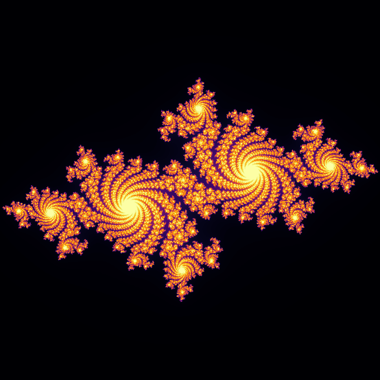

We could experiment with running julia2.py over and over with different inputs, but it's very easy to create an interactive widget using ipywidgets. First `%load` julia2.py and run that cell.

```python
# %load julia2.py
import numpy as np
import matplotlib.pyplot as plt
import argparse

def generate_julia(zoom=1, move_x=0, move_y=0,
                   c_real=-0.7, c_imag=0.27, max_iter=300):
    """
    Generate and save a Julia set fractal image.

    Parameters:
        zoom (float): Zoom factor (>0).
        move_x, move_y (float): Pan offsets.
        c_real, c_imag (float): Complex constant defining the Julia set.
        max_iter (int): Maximum iterations for escape time algorithm.
    """
    # Validate parameters
    if zoom <= 0:
        raise ValueError("Zoom factor must be positive.")
    if max_iter <= 0:
        raise ValueError("max_iter must be a positive integer.")

    # Create a complex grid
    width=1000
    height=1000
    x = np.linspace(-1.5, 1.5, width) / zoom + move_x
    y = np.linspace(-1.5, 1.5, height) / zoom + move_y
    X, Y = np.meshgrid(x, y)
    Z = X + 1j * Y

    # Julia set calculation
    C = complex(c_real, c_imag)
    img = np.zeros(Z.shape, dtype=int)

    for i in range(max_iter):
        mask = np.abs(Z) < 4
        Z[mask] = Z[mask] ** 2 + C #Iteration: z = z^2 + C
        img[mask] = i

    # Plot
    plt.figure(figsize=(8, 8))
    plt.imshow(img, cmap="inferno", extent=(-1.5, 1.5, -1.5, 1.5))
    plt.axis("off")
    plt.tight_layout()


if __name__ == "__main__":
    parser = argparse.ArgumentParser(formatter_class=argparse.ArgumentDefaultsHelpFormatter)

    parser.add_argument('-r', default=-0.7, help = 'real constant')
    parser.add_argument('-i', default=0.27, help = 'imaginary constant')
    parser.add_argument('-z', default=1, help = 'zoom factor')
    parser.add_argument('-x', default=0, help = 'pan offset x')
    parser.add_argument('-y', default=0, help = 'pan offset y')
    parser.add_argument('-m', default=300, help = 'max iterations')
    parser.add_argument('-o', default='julia.png', help = 'output file name')

    args = parser.parse_known_args()[0]

    try:
        # Example: Generate a Julia set with parameters
        generate_julia(zoom=float(args.z), move_x=int(args.x), move_y=int(args.y),
                       c_real=float(args.r), c_imag=float(args.i), max_iter=int(args.m))

        # save and close plot
        plt.savefig(args.o, dpi=72, bbox_inches='tight', pad_inches=0)
        print(f"Julia set image saved as '{args.o}'")
        plt.close()

    except Exception as e:
        print(f"Error: {e}")
```

[output not shown]

This ran the python script just like before, but now we have the `generate_julia` function defined in our notebook.

```python
generate_julia?
```

```
Signature:
generate_julia(
    zoom=1,
    move_x=0,
    move_y=0,
    c_real=-0.7,
    c_imag=0.27,
    max_iter=300,
)
Docstring:
Generate and save a Julia set fractal image.

Parameters:
    zoom (float): Zoom factor (>0).
    move_x, move_y (float): Pan offsets.
    c_real, c_imag (float): Complex constant defining the Julia set.
    max_iter (int): Maximum iterations for escape time algorithm.
File:      /gpfs/home/emwin/jupyter-f26/julia2.py
Type:      function
```

We can run this function and change different parameters:

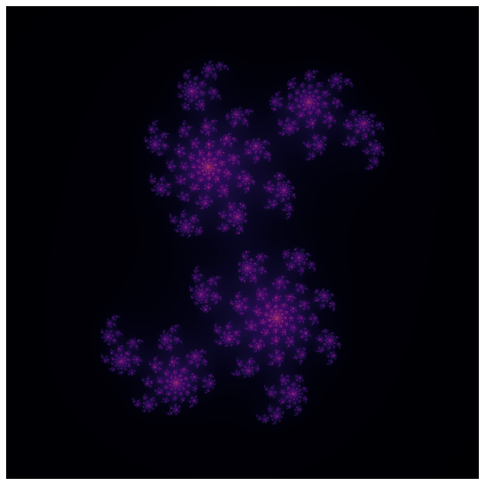

```python
generate_julia(c_real=0.4)
```

But we can also change these parameters interactively!

```python
from ipywidgets import interact
```

```python
interact(generate_julia);
```

```
interactive(children=(IntSlider(value=1, description='zoom', max=3, min=-1), IntSlider(value=0, description='m…
```

ipywidgets will do its best to guess what widgets to use, but if it chooses badly we can set the ranges explicitly

```python
interact(generate_julia, c_imag=(-1.0,1.0,.01));
```

```
interactive(children=(IntSlider(value=1, description='zoom', max=3, min=-1), IntSlider(value=0, description='m…
```

Important thing to keep in mind: when we stop this kernel, any interactive widgets will stop showing their output. Interactive widgets are also not recorded in logfiles. If you do anything that you want to keep as a permanent record, make sure to record it in some way.

# Exercise 6: Interactive functions

- Add limits to every variable in your call to `interact` until no errors are thrown
- Play with the sliders until you get an image that you like
- Run julia2.py with those parameters to create a new output
  - option 1: the `%run` magic, eg: `%run julia2.py -r 0.4 -i 0.27 -o my_julia.png`
  - option 2: as a system call, eg: `!python julia2.py -r 0.4 -i 0.27 -o my_julia.png`
- Create a new markdown cell
- Drag the image you created into the markdown cell

```python
interact(generate_julia, c_imag=(-1.0,1.0,.01));
```

```
interactive(children=(IntSlider(value=1, description='zoom', max=3, min=-1), IntSlider(value=0, description='m…
```